# Final Report

Jane Huber

3/28/2022

# 1 Introduction

Homes in Detroit have suffered from poorly assessed home values, which has contributed greatly to foreclosure during a time of economic instability. The UC Irvine Law Review’s [“Taxed Out: Illegal Property Tax Assessments and the Epidemic of Tax Foreclosures in Detroit”](https://scholarship.law.uci.edu/ucilr/vol9/iss4/3/) analyzes the relationship between over-assessing a home and its role in driving foreclosures, exposing government’s role in creating conditions for people to lose their homes. The Harris School of Public Policy at the University of Chicago’s The Center For Municipal Finance produced the report [“An Evaluation of Residential Property Tax Assessments in the City of Detroit, 2016-2018”](https://harris.uchicago.edu/files/evalrespropertytaxasdetroit20162018.pdf) shows how the city of Detroit attempted to correct that mistake, reducing the number of assessments higher than sales, but that it’s still too high.

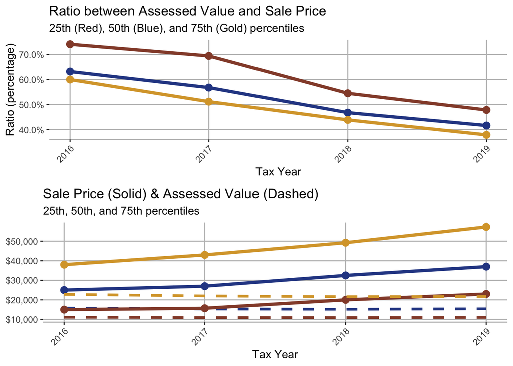

# 2 New Assessment Models (Part A)

| measurement | initial_model | with_additional_values |
| --- | --- | --- |
| true positive rate | 0.2314607 | 0.2260128 |
| true negative rate | 0.1169231 | 0.1171750 |
| false positive rate | 0.8830769 | 0.8828250 |
| false negative rate | 0.7685393 | 0.7739872 |
| positive predictive value | 0.1521418 | 0.1615854 |

| first_RMSE | second_RMSE |
| --- | --- |
| 25894.3 | 28436.6 |

# 3 Comparison

| neighbors | weight_func | dist_power | .config |
| --- | --- | --- | --- |
| 10 | rectangular | 1.812746 | Preprocessor1_Model11 |

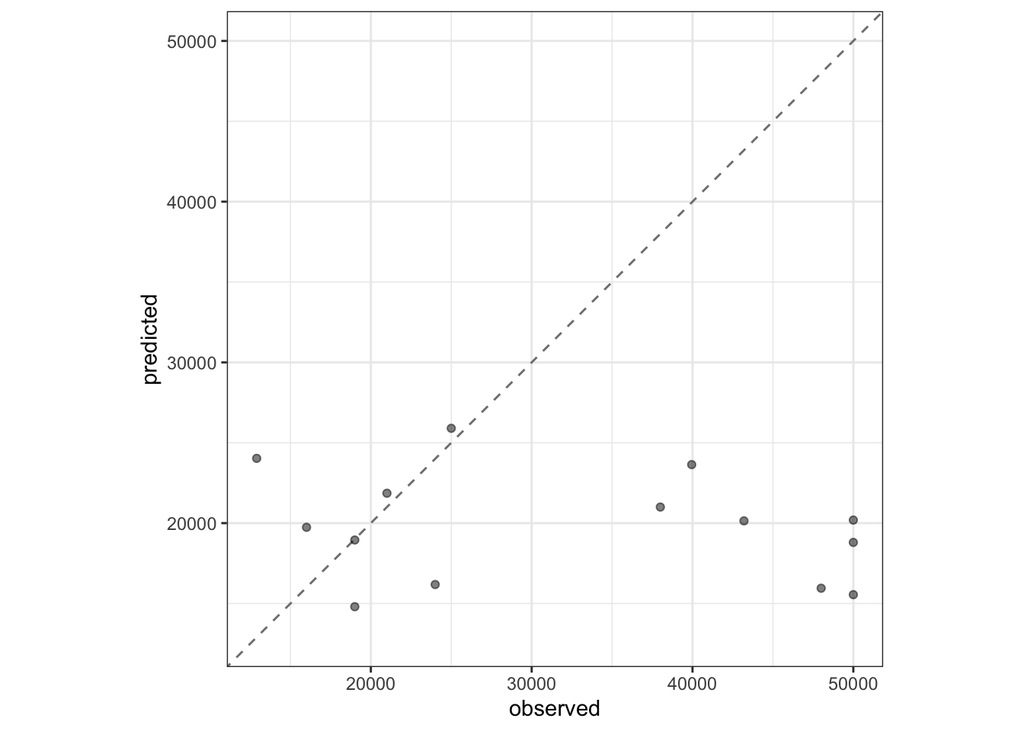

# 4 Hyperparameter Exploration for Classification (Part B)

When exploring our classification model, we can tune the hyperparameters using an SVM model to see how well we are able to predict the likelihood of overassessment by the assessor.

| cost | rbf_sigma | .metric | .estimator | mean | n | std_err | .config | .iter |
| --- | --- | --- | --- | --- | --- | --- | --- | --- |
| 28.9609644 | 0.0088594473 | roc_auc | binary | 0.9197020 | 3 | 0.008095798 | Iter2 | 2 |
| 31.9296221 | 0.0028905069 | roc_auc | binary | 0.9188572 | 3 | 0.007698594 | Iter5 | 5 |
| 29.7242095 | 0.0005974637 | roc_auc | binary | 0.9176545 | 3 | 0.008055695 | Iter4 | 4 |
| 0.2332644 | 0.0002286182 | roc_auc | binary | 0.8843615 | 3 | 0.002485973 | Preprocessor1_Model2 | 0 |
| 28.3479599 | 0.7680925443 | roc_auc | binary | 0.8772100 | 3 | 0.007333924 | Iter3 | 3 |

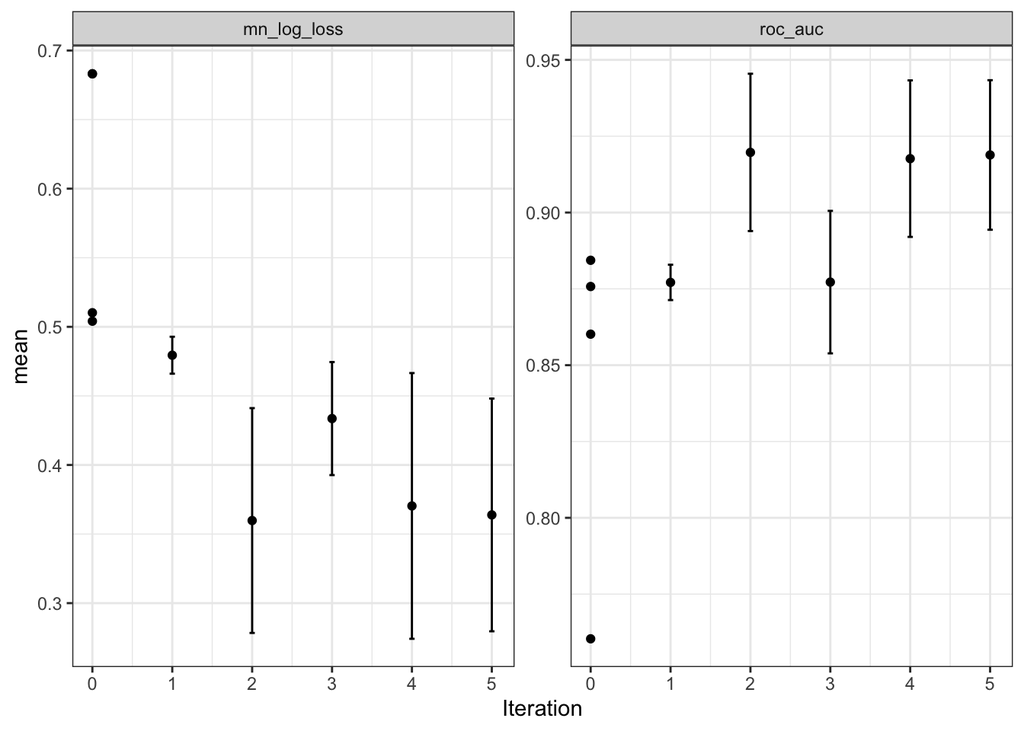

# 5 Conclusion (Part C)

The consequences of poor assessments in Detroit has been significant and caused a great deal of harm to Detroit residents, exacerbating inequality and contributing to a high number of home foreclosures in the city. It is not a particularly transparent process and, while we may have suspicions of their methodology, the assessor has not publicly shared the details of their process.There are a number of problems that impact the ability of the assessor to create accurate assessments, in particular data quality and detail. Most assessors around the country struggle to create accurate assessments while respecting the privacy of homeowners and Detroit is no different. However, all these factors combined contribute to poor quality of assessments. Residents of Detroit deserve better–and fairer–from their elected officials.

The models that I was able to generate face the same issues as the Detroit assessor’s office in terms of quality and lack of details that may contribute to home value. I believe my model is quite effective at identifying whether or not something will be overassessed, but I do not believe that my sale price prediction model has an impressive RMSE. Further tuning the models and their hyperparameters helped me to identify more effective models.

Big picture, when evaluating whether Detroit should adopt this model, there are some ethical concerns that hold me back from suggesting they implement the model. Even if the model “performs better” than Detroit’s assessments when compared with sale price (we would have to compare the Coefficient of Differential to determine that), I argue that extreme caution and hesitancy should be used when applying ML models to assessments. The lack of transparency that my models produce means that Detroit would replace one un-transparent tool with another, although perhaps with less accountability because “the algorithm” can be blamed more than an elected official. Additionally, poor data quality should make us hesitant to base future home assessments to squarely on patterns seen in the past. Since the harm caused by unfair assessments can be huge and lead to foreclosures, creating tools that could potentially reaffirm systemic bias should be evaluated extremely closely. Layering in a history of racism and [“redlinng”](https://www.canr.msu.edu/redlining/detroit), we should be hesitant to claim that qualities in historic sale values are an effective tool to give a fair assessment to homeowners. Furthermore, I believe that we should have significant concerns around applying a model that cart blanche seeks to generate assessments without factoring in equity may not effectively address overall concerns with assessments in Detroit. While this model may be a step in the right direction, I believe all these topics must be addressed and agreed upon by the public and elected officials before this experiment is conducted.